# Lesson 8 Course Project

Jerry Siah

21 July 2015

### Introduction

Using devices such as Jawbone Up, Nike FuelBand, and Fitbit it is now possible to collect a large amount of data about personal activity relatively inexpensively. In this project, we will use data from accelerometers on the belt, forearm, arm, and dumbell of 6 participants. These participants were asked to perform barbell lifts correctly and incorrectly in 5 different ways. The goal of this project is to predict the manner in which they did the exercise.

### Analysis

First, we load the necessary libraries, set the seed for reproducibility of the analysis, and load the data sets, setting blank fields as NAs.

```r
library(caret)
library(randomForest)
```

```r
library(corrplot)
library(rpart)
library(rpart.plot)

set.seed(12345)

#training and testing data files are assumed to be in the working directory
training <- read.csv("pml-training.csv", na.strings= c("NA",""," "))
testing <- read.csv("pml-testing.csv", na.strings= c("NA",""," "))
```

Next, we perform data cleansing by removing columns with NAs and columns not revelant to the accelerometer readings.

```r
#keep only columns without NAs
training_clean <- training[,colSums(is.na(training)) == 0]

#remove the first 7 columns of the data which is not related to the accelerometers
training_clean <- training_clean[8:length(training_clean)]
```

From the training set, we split the data set into 70% as the training set and the remaining 30% as cross validation set.

```r
#split the cleansed training data into training and cross validation data sets
inTrain <- createDataPartition(y = training_clean$classe, p = 0.7, list = FALSE)
training <- training_clean[inTrain, ]
crossvalidation <- training_clean[-inTrain, ]
```

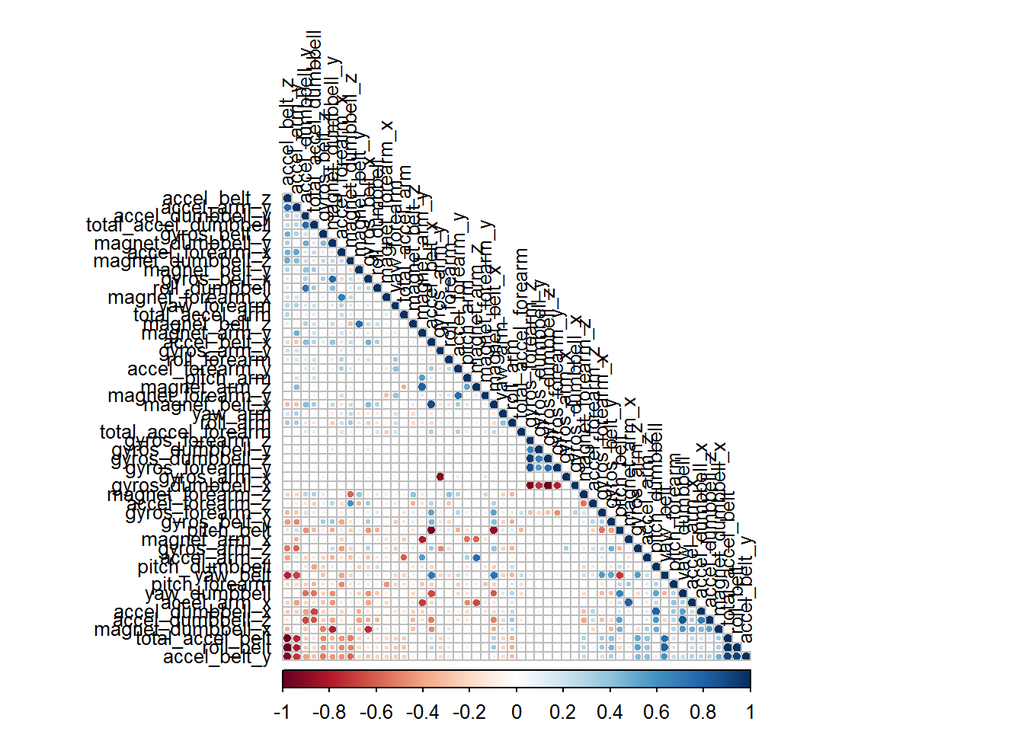

```r
#correlation matrix
correlationMatrix <- cor(training[, -length(training)])
corrplot(correlationMatrix, order = "FPC", method = "circle", type = "lower", tl.cex = 0.8,  tl.col = rgb(0, 0, 0))
```

```r
#corrplot(correlationMatrix, method = "color")
```

Since the outcome (classe) is a categorical feature, we use Random Forest algorithm which is able to classify large amounts of data with accuracy. It is able to overcome the problems of high variance and high bias by averaging, hence, minimising out of sample error.

```r
#fit a model to predict the classe variable using all other variables as predictors

modFit <- randomForest(classe ~ ., data = training)

#crossvalidate the model using the remaining 30% of data

prediction <- predict(modFit, crossvalidation)
confusionMatrix(crossvalidation$classe, prediction)
```

```
## Confusion Matrix and Statistics
##
##           Reference
## Prediction    A    B    C    D    E
##          A 1673    1    0    0    0
##          B   10 1126    3    0    0
##          C    0   10 1015    1    0
##          D    0    0   14  950    0
##          E    0    0    0    5 1077
##
## Overall Statistics
##
##                Accuracy : 0.9925
##                  95% CI : (0.99, 0.9946)
##     No Information Rate : 0.286
##     P-Value [Acc > NIR] : < 2.2e-16
##
##                   Kappa : 0.9905
##  Mcnemar's Test P-Value : NA
##
## Statistics by Class:
##
##                      Class: A Class: B Class: C Class: D Class: E
## Sensitivity            0.9941   0.9903   0.9835   0.9937   1.0000
## Specificity            0.9998   0.9973   0.9977   0.9972   0.9990
## Pos Pred Value         0.9994   0.9886   0.9893   0.9855   0.9954
## Neg Pred Value         0.9976   0.9977   0.9965   0.9988   1.0000
## Prevalence             0.2860   0.1932   0.1754   0.1624   0.1830
## Detection Rate         0.2843   0.1913   0.1725   0.1614   0.1830
## Detection Prevalence   0.2845   0.1935   0.1743   0.1638   0.1839
## Balanced Accuracy      0.9969   0.9938   0.9906   0.9954   0.9995
```

### Conclusion

From the results above, we have 99% accuracy when we did the cross-validation. We could use the model to determine the answers for the test data set.

```r
#apply same cleansing method to the testing data
testing_clean <- testing[,colSums(is.na(testing))==0]
testing_clean <- testing_clean[8:length(testing_clean)]

#predict the classe variable of the test set
predictionTest <- predict(modFit, testing_clean)
predictionTest
```

```
##  1  2  3  4  5  6  7  8  9 10 11 12 13 14 15 16 17 18 19 20
##  B  A  B  A  A  E  D  B  A  A  B  C  B  A  E  E  A  B  B  B
## Levels: A B C D E
```

```r
answers <- as.character(predictionTest)

pml_write_files = function(x){
    n = length(x)
    for(i in 1:n){
        filename = paste0("problem_id_",i,".txt")
        write.table(x[i],file=filename,quote=FALSE,row.names=FALSE,col.names=FALSE)
    }
}

pml_write_files(answers)
```

### Appendix

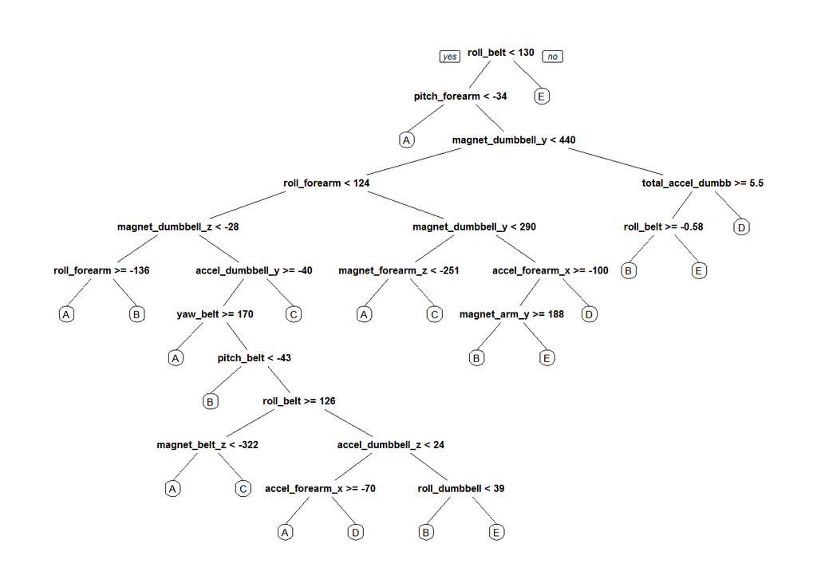

```r
#decision tree
treeModel <- rpart(classe ~ ., data=training, method="class")
prp(treeModel)
```